# MNIST Card Data

We compare the methods used with our methods with a more standard dataset used in this paper **Mukhoti, J., Kirsch, A., van Amersfoort, J., Torr, P. H. S., & Gal, Y. (2021). Deterministic Neural Networks with Appropriate Inductive Biases Capture Epistemic and Aleatoric Uncertainty. http://arxiv.org/abs/2102.11582**.

We used

- MNIST: Handwritten digits from 0 to 9 as in-ditribution and training images;
- AmbiguousMNIST: Ambiguous handwritten digits, as ambiguous data;
- FashionMNSIT: Clothes images within the same format as novel data;

```python
import tensorflow as tf
import numpy as np
import matplotlib.pyplot as plt
import pandas as pd
from sklearn.decomposition import PCA

%load_ext autoreload
%autoreload 2

import sys
sys.path.append("..")
from common.utilities import Data
from common.figures import Figures
from matplotlib import rc
rc('font',**{'family':'serif','serif':['Palatino']})
plt.rcParams['pdf.fonttype'] = 42
```

```
The autoreload extension is already loaded. To reload it, use:
  %reload_ext autoreload
```

```python
filepath = "./datasets/processed_data/mnist_data.pkl"
train, test, uncertain = Data.get_dataset(filepath = filepath)
(z_train, y_train), (z_test, y_test), z_uncertain = Data.dataframe2arrays(train, test, uncertain)
```

```
Dataset loaded...
Number of images:  600
Features:  name, class_label, uncertainty_label, group, X_PIL, X_array, X_mobilenet, y_onehot, y, z_ensemble
Labels:  0.0, 1.0, 2.0, 3.0, 4.0, 5.0, 6.0, 7.0, 8.0, 9.0, nan
Training set size:  160
Testing set size:  200
Uncertain pool size:  240
```

Let's have a look to the in-distribution training data and uncertain data.

```python
# Training data
cpt = 0.
X_train = []
for i, img in enumerate(np.concatenate((train["X_PIL"].values,train["X_PIL"].values), axis = 0)
):
    i= i %160
    if train["class_label"].values[i] == float(cpt):
       X_train.append(tf.keras.preprocessing.image.img_to_array(img)/255.0)
       cpt=(cpt+1.)%10

X_train = np.array(X_train)
fig = Figures.image_grid(np.concatenate((X_train[:5],X_train[10:15],X_train[5:10],X_train[15:20]), axis=0), 5)
fig.savefig("MNIST_certain.pdf", bbox_inches='tight')
```

[output not shown]

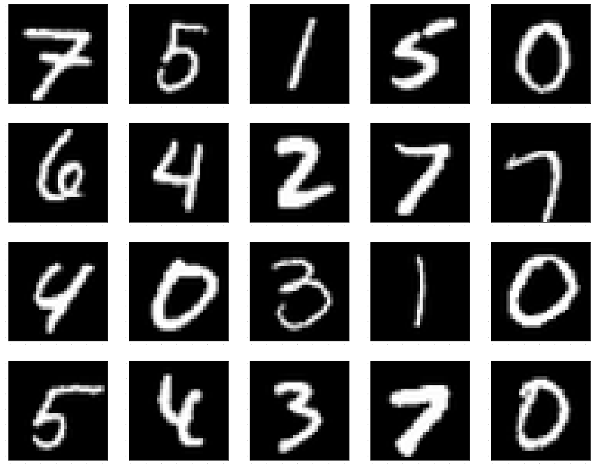

```python
# Test data
X_test = [tf.keras.preprocessing.image.img_to_array(img) for img in test['X_PIL'].values]
Figures.image_grid(X_test[:20], 5)
```

[output not shown]

```python
# Uncertain data
X_uncertain_ = [tf.keras.preprocessing.image.img_to_array(img) for img in uncertain['X_PIL'].values]
fig = Figures.image_grid(X_uncertain_[:20], 5)
fig.savefig("MNIST_uncertain.pdf", bbox_inches='tight')
```

[output not shown]

## Data analysis in the feature space

To speed up the training and enable interactive and incremental training during the user study, we had to perform transfer learning. To do so, we investigated embeddings that transform our data into a feature space.

We investigate three different embeedings:

- MobileNetV1,
- MobileNetV2,
- ResNet50,

Of course, it seems useless to use such embeddings with MNIST images that are 28x28 pixels. Indeed, the ResNet50 pre-logit layer output is larger than the initial image. However, for the sake of the comparison with our playing card data, we still use these embeddings for the benchamrk. We also resample the image to have 32x32 pixels, that is the minimum size for the embeddings to be able to process the data.

To better estimate the richness and the variance distribution within the feature spaces, we perform Principal Component Analysis (PCA).

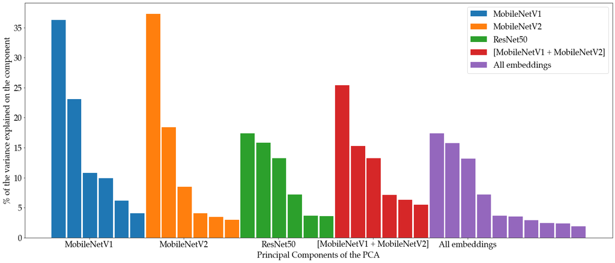

```python
var = Figures.scree_plot(z_train, z_test, z_uncertain)
```

We compute the Shannon entropy using the 10 first eigen-values of the Principal Analysis decomposition.

```python
import scipy
names = ["MobileNetV1", "MobileNetV2", "ResNet50", "MobileNetV1+MobileNetV2", "All embeddings concatenated"]
for i in range(len(var)):
    print(names[i], " : ", scipy.stats.entropy(var[i]))
```

```
MobileNetV1  :  1.7227495
MobileNetV2  :  1.6930317
ResNet50  :  1.9929383
MobileNetV1+MobileNetV2  :  1.9773712
All embeddings concatenated  :  1.993009
```

**Observation**: Depending on the embedding, the variance in the data is more or less distributed among the principal components:

The Shannon entropy on the 10 first eigen values of the PCA is a good indicator of the variance distribution among the components. We might expect better separation between uncertain and certain data with ResNet50 since the variance is more distributed across several dimension.

Let's vizualize the feature space for these two embeedings.

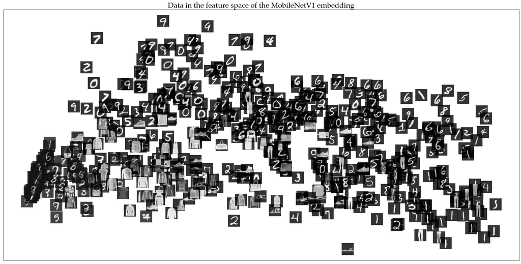

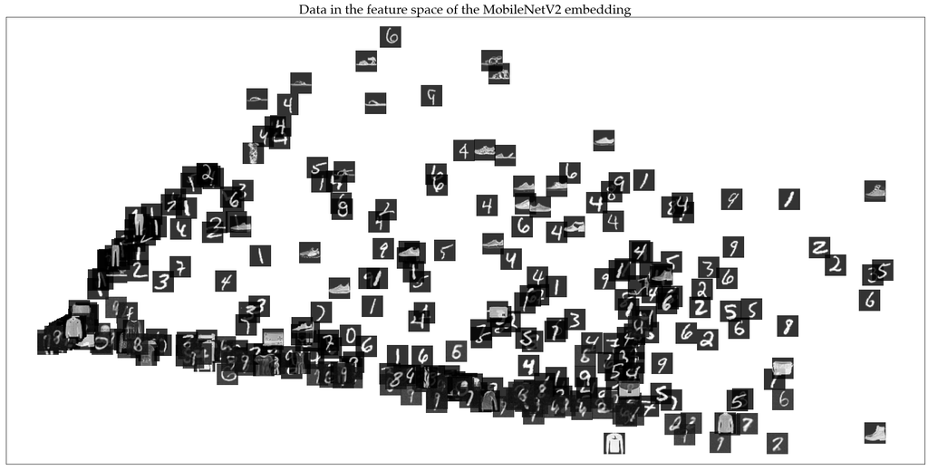

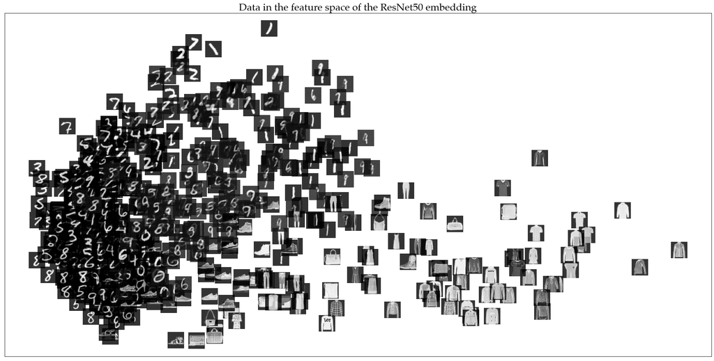

```python
embeddings: dict = {0: "MobileNetV1", 1: "MobileNetV2", 2: "ResNet50", 3: "[MobileNetV1 + MobileNetV2]", 4: "All embeddings"}
z_all = np.concatenate((z_train, z_test, z_uncertain), axis = 0)
all_data = pd.concat([train, test, uncertain])
image_all = list(all_data["X_PIL"].values)
for i in [0,1,2]:
    z =Data.select_embedding(z_all, i)
    pca = PCA(n_components=10, svd_solver='full')
    z_all_2D = pca.fit(z).transform(z)
    plt.figure(figsize=(30,15))
    for j in range(len(image_all)):
        Figures.imscatter(z_all_2D[:,0][j], z_all_2D[:,1][j], image_all[j], ax=None, zoom=1.2)
        plt.title("Data in the feature space of the {0} embedding".format(embeddings[i]))
```

**Observations**: The separation between the different type of ambiguity seems more coherent within the ResNet50 embedding.

We further analyze the ability of our uncertainty measures to separate our data in the next notebook: 2_uncertainty_estimations_mnnist.ipynb. You can return to the index here.